# R_Case_Study

Hadrien

2022-09-15

*Libraries used*

```r
library(tidyverse)
library(readxl)
library(qpcR)
library(fastDummies)
library(janitor)
library(kableExtra)
library(GGally)
library(huxtable)
```

# 1. Exploring the data

## 1.1. Import the data

We start by importing into R the price data from the Excel file by fetching it from the second tab of the spreadsheet.

```r
#read the data from the Excel file
insurance_data <- read_excel("C:/Users/Hadrien Pistre/OneDrive - Pearson Ham Consulting Ltd/Desktop/R Folder/PH_training/Brief for Interview_Analyst.xlsx", sheet = 2)
#replace wrong colnammes with the right colnames that are on the data set's first row
colnames(insurance_data) <- insurance_data[1,]

#delete the first row which is now a duplicate of the colnames
insurance_data <- insurance_data[-1,]
```

## 1.2. Format the data

We then examine the types of data we imported. + This data contains only 3 rows containing NAs out of more than 20K rows: we thus decide to delete those rows since their explanatory power is negligible given their small number. + Variables containing numbers are stored as characters on the original data file. We decide to convert those variables to numeric variables. + To be able to analyze categorical variables, we decide to create N-1 dummies for each of those variables. + Finally, after a qualitative examination, we conclude than only variables 7 to 9 may be colinear. We create a colinear matrix using ggpairs and determine that variables 8 and 9 are colinear; we hence decide to remove variable 9 from our dataset.

```
## tibble [20,020 × 14] (S3: tbl_df/tbl/data.frame)
##  $ Marital Status                       : chr [1:20020] "M" "M" "S" "M" ...
##  $ AGE                                  : chr [1:20020] "45" "40" "25" "42" ...
##  $ Gender                               : chr [1:20020] "F" "M" "F" "M" ...
##  $ Car Value                            : chr [1:20020] "500" "3000" "4000" "1800" ...
##  $ Years of No Claims Bonus             : chr [1:20020] "4" "8" "4" "9" ...
##  $ Annual Mileage                       : chr [1:20020] "6000" "6000" "4000" "10000" ...
##  $ Payment Method                       : chr [1:20020] "Monthly" "Monthly" "Monthly" "Annual" ...
##  $ Acquisition Channel                  : chr [1:20020] "Inbound" "Inbound" "Inbound" "Inbound" ...
##  $ Years of Tenure with Current Provider: chr [1:20020] "4" "4" "4" "4" ...
##  $ Price                                : chr [1:20020] "289.35000000000002" "170.4" "466.13" "245.1" ...
##  $ Actual Change in Price vs last Year  : chr [1:20020] "-11.941498709999962" "45.617083578000006" "-123.14999999999998" "2.3400000000000034" ...
##  $ % Change in Price vs last Year       : chr [1:20020] "-3.9634369907973838E-2" "0.36557154525647417" "-0.20898384469182729" "9.6391497775580957E-3" ...
##  $ Grouped Change in Price              : chr [1:20020] "-0.05" "0.35" "-0.2" "0" ...
##  $ Renewed?                             : chr [1:20020] "0" "1" "1" "1" ...
```

| Variable | Number of NAs |
| --- | --- |
| Marital Status | 0 |
| AGE | 0 |
| Gender | 0 |
| Car Value | 0 |
| Years of No Claims Bonus | 0 |
| Annual Mileage | 0 |
| Payment Method | 0 |
| Acquisition Channel | 0 |
| Years of Tenure with Current Provider | 0 |
| Price | 3 |
| Actual Change in Price vs last Year | 3 |
| % Change in Price vs last Year | 3 |
| Grouped Change in Price | 3 |
| Renewed? | 0 |

| marital_status | gender | payment_method | acquisition_channel | renewed |
| --- | --- | --- | --- | --- |
| M | F | Monthly | Inbound | 0 |
| S | M | Annual | Direct | 1 |
| D | C |  | Aggreg |  |
| W |  |  | Outbound |  |
| V |  |  |  |  |

```
## tibble [20,017 × 20] (S3: tbl_df/tbl/data.frame)
##  $ age                                  : num [1:20017] 45 40 25 42 59 54 39 29 25 33 ...
##  $ car_value                            : num [1:20017] 500 3000 4000 1800 5000 2500 300 800 800 1000 ...
##  $ years_of_no_claims_bonus             : num [1:20017] 4 8 4 9 9 6 9 9 3 6 ...
##  $ annual_mileage                       : num [1:20017] 6000 6000 4000 10000 3000 3000 10000 7000 5000 8000 ...
##  $ years_of_tenure_with_current_provider: num [1:20017] 4 4 4 4 4 4 4 4 4 4 ...
##  $ price                                : num [1:20017] 289 170 466 245 240 ...
##  $ actual_change_in_price_vs_last_year  : num [1:20017] -11.94 45.62 -123.15 2.34 42.56 ...
##  $ percent_change_in_price_vs_last_year : num [1:20017] -0.03963 0.36557 -0.20898 0.00964 0.21501 ...
##  $ grouped_change_in_price              : num [1:20017] -0.05 0.35 -0.2 0 0.2 0.05 0 0.35 -0.25 -0.05 ...
##  $ renewed                              : num [1:20017] 0 1 1 1 0 0 1 1 0 1 ...
##  $ marital_status_d                     : num [1:20017] 0 0 0 0 0 0 0 0 0 0 ...
##  $ marital_status_m                     : num [1:20017] 1 1 0 1 1 1 1 1 0 0 ...
##  $ marital_status_s                     : num [1:20017] 0 0 1 0 0 0 0 0 1 1 ...
##  $ marital_status_v                     : num [1:20017] 0 0 0 0 0 0 0 0 0 0 ...
##  $ gender_f                             : num [1:20017] 1 0 1 0 0 1 1 0 0 0 ...
##  $ gender_m                             : num [1:20017] 0 1 0 1 1 0 0 1 1 1 ...
##  $ payment_method_annual                : num [1:20017] 0 0 0 1 1 1 0 0 0 1 ...
##  $ acquisition_channel_aggreg           : num [1:20017] 0 0 0 0 0 0 0 0 0 0 ...
##  $ acquisition_channel_direct           : num [1:20017] 0 0 0 0 0 0 0 0 0 0 ...
##  $ acquisition_channel_inbound          : num [1:20017] 1 1 1 1 1 1 1 1 1 1 ...
##  - attr(*, "na.action")= 'omit' Named int [1:3] 6544 7369 9082
##   ..- attr(*, "names")= chr [1:3] "6544" "7369" "9082"
##  - attr(*, ".internal.selfref")=<externalptr>
```

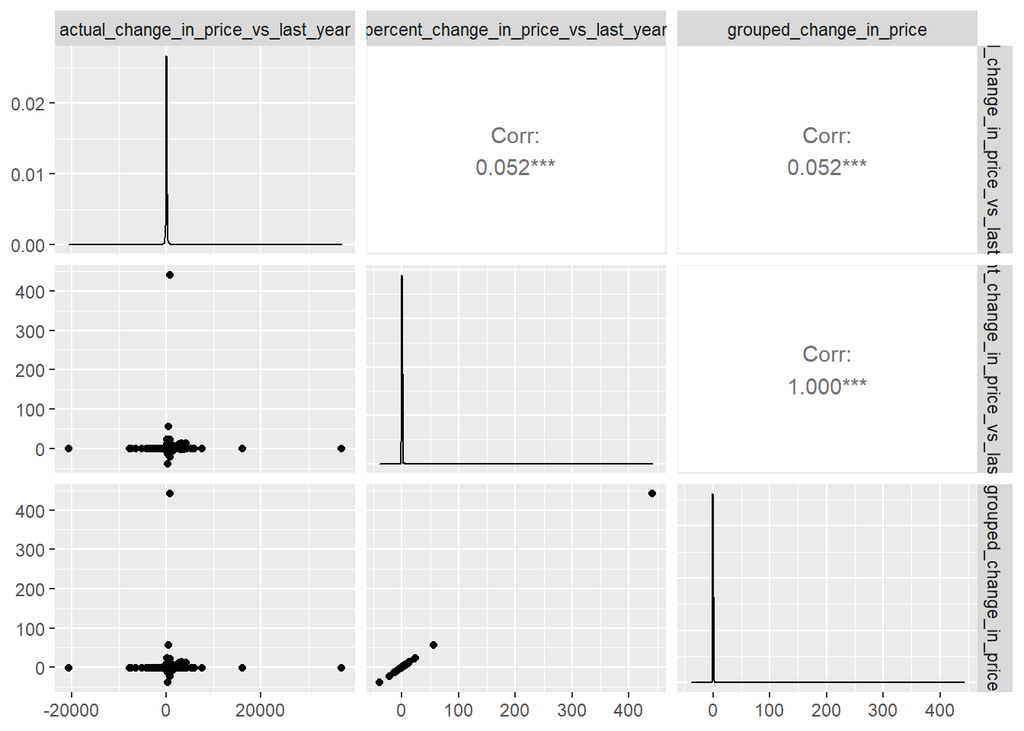

# 2. Analyse the factors that drive price

## 2.1. Vizualise the data

### 2.1.1. Examine distributions

We want to visualize the individual impact of each variable on price. We first plot the distribution of all non-dummy variables to examine if they contain outliers that could make our data visualization less relevant.

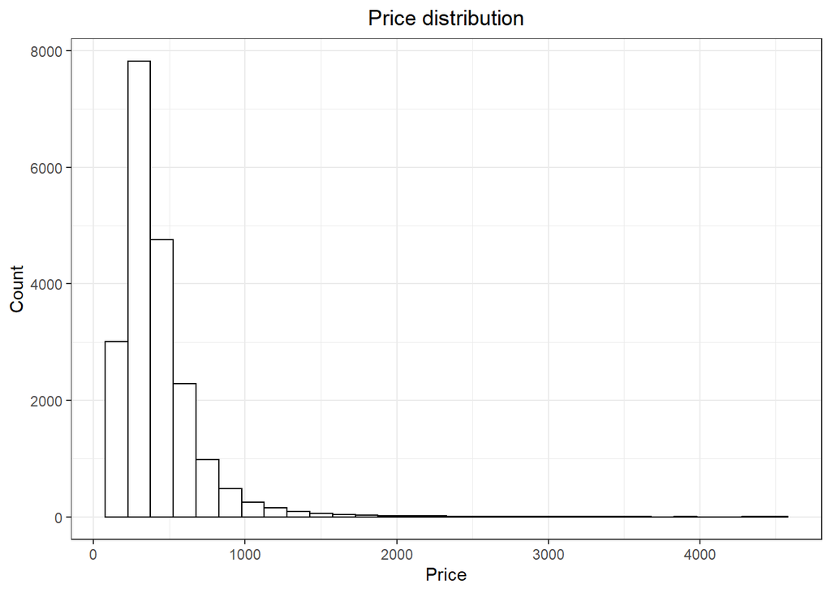

```r
#create histograms of each non-dummy variable

#price
ggplot(insurance_data_dummied_short, aes(x=price))+
  geom_histogram(color="black", fill="white")+
  theme_bw()+
  labs(x="Price",y="Count",title="Price distribution")+
  theme(plot.title = element_text(hjust = 0.5))
```

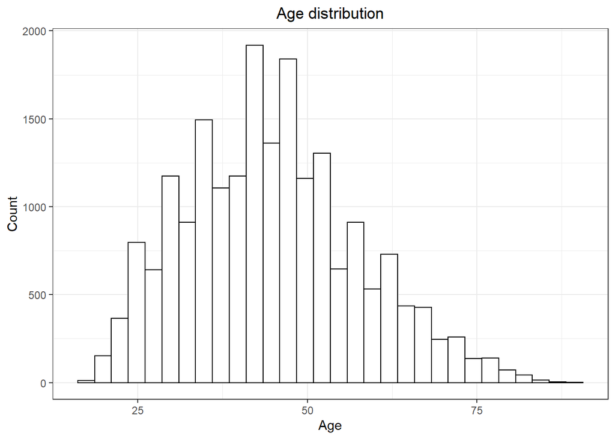

```r
#age
ggplot(insurance_data_dummied_short, aes(x=age))+
  geom_histogram(color="black", fill="white")+
  theme_bw()+
  labs(x="Age",y="Count",title="Age distribution")+
  theme(plot.title = element_text(hjust = 0.5))
```

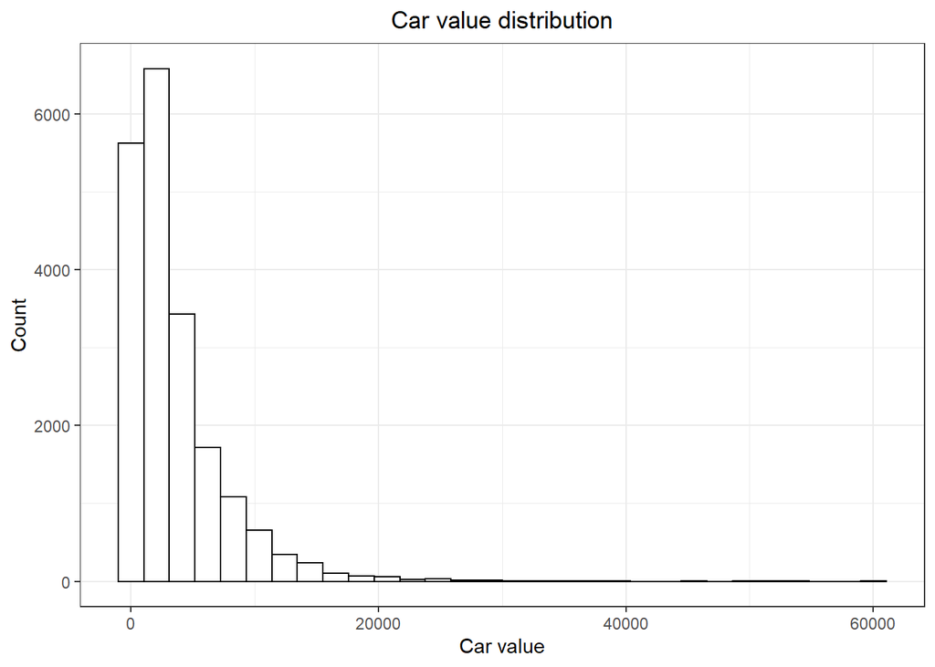

```r
#car value
ggplot(insurance_data_dummied_short, aes(x=car_value))+
  geom_histogram(color="black", fill="white")+
  theme_bw()+
  labs(x="Car value",y="Count",title="Car value distribution")+
  theme(plot.title = element_text(hjust = 0.5))
```

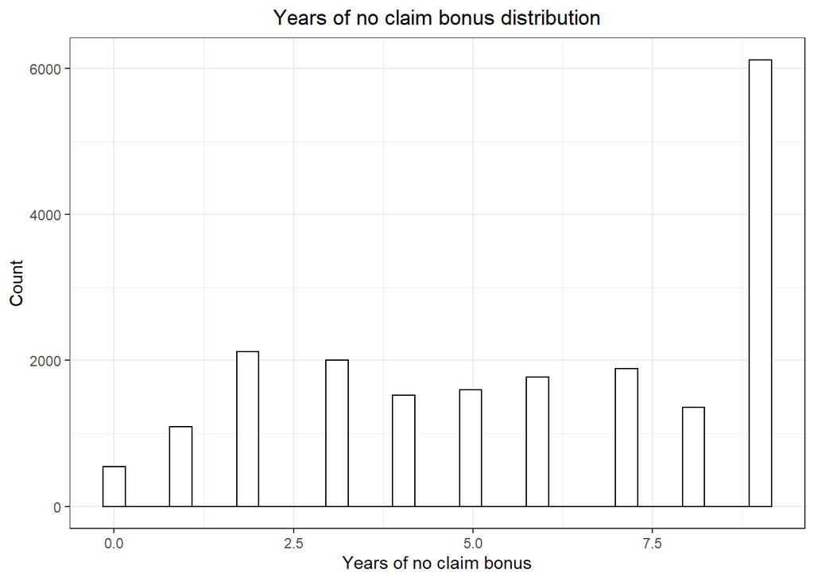

```r
#years of no claim bonus
ggplot(insurance_data_dummied_short, aes(x=years_of_no_claims_bonus))+
  geom_histogram(color="black", fill="white")+
  theme_bw()+
  labs(x="Years of no claim bonus",y="Count",title="Years of no claim bonus distribution")+
  theme(plot.title = element_text(hjust = 0.5))
```

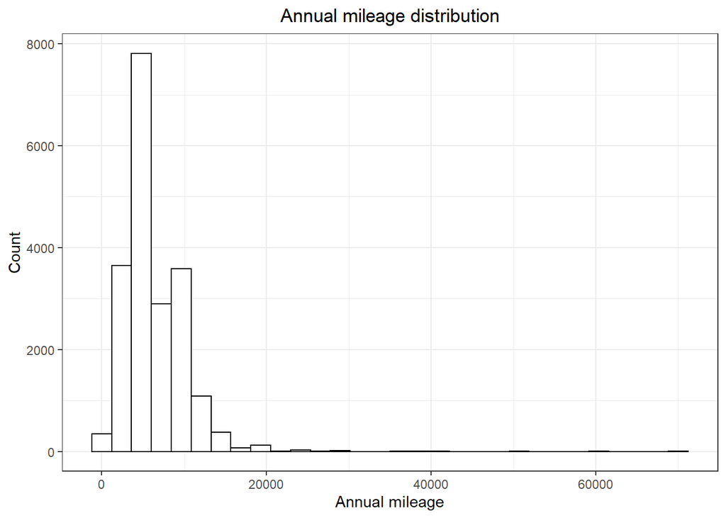

```r
#annual mileage
ggplot(insurance_data_dummied_short, aes(x=annual_mileage))+
  geom_histogram(color="black", fill="white")+
  theme_bw()+
  labs(x="Annual mileage",y="Count",title="Annual mileage distribution")+
  theme(plot.title = element_text(hjust = 0.5))
```

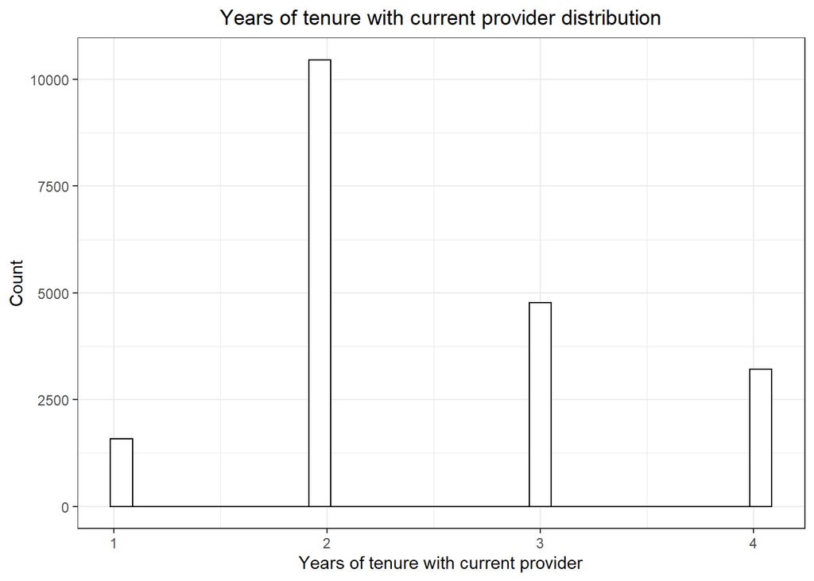

```r
#year of tenure with current provider
ggplot(insurance_data_dummied_short, aes(x=years_of_tenure_with_current_provider))+
  geom_histogram(color="black", fill="white")+
  theme_bw()+
  labs(x="Years of tenure with current provider",y="Count",title="Years of tenure with current provider distribution")+
  theme(plot.title = element_text(hjust = 0.5))
```

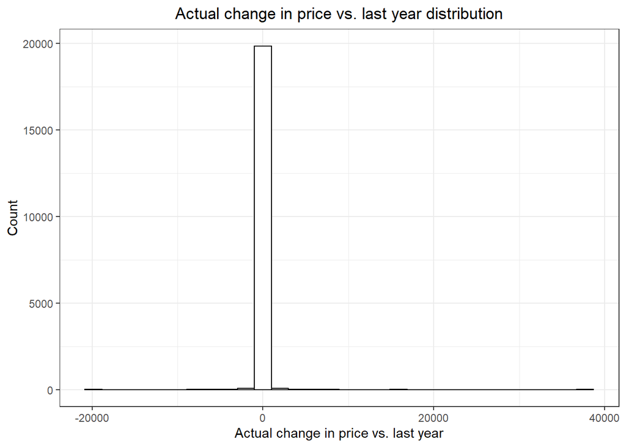

```r
#actual change in price vs. last year
ggplot(insurance_data_dummied_short, aes(x=actual_change_in_price_vs_last_year))+
  geom_histogram(color="black", fill="white")+
  theme_bw()+
  labs(x="Actual change in price vs. last year",y="Count",title="Actual change in price vs. last year distribution")+
  theme(plot.title = element_text(hjust = 0.5))
```

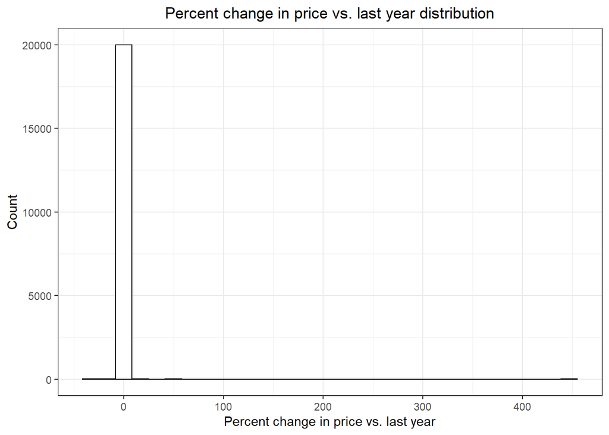

```r
#percent change in price vs last year
ggplot(insurance_data_dummied_short, aes(x=percent_change_in_price_vs_last_year))+
  geom_histogram(color="black", fill="white")+
  theme_bw()+
  labs(x="Percent change in price vs. last year",y="Count",title="Percent change in price vs. last year distribution")+
  theme(plot.title = element_text(hjust = 0.5))
```

### 2.1.2. Examine distributions without outliers

We notice that the variables “Car value”, “Annual mileage distribution”, “Actual change in price vs. last year” and “Percent change in price vs. last year” contain significant outliers. We get rid of the last percentile of the first two variables and of the first and last percentiles of the last two variables to vizualise them properly. We notice that this greatly improve the visualization of their distribution.

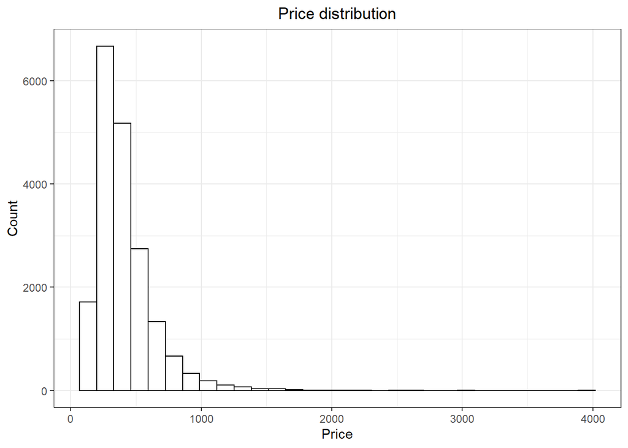

```r
#get rid of the extreme percentiles to improve our data visualization
insurance_data_dummied_short_no_outliers <- subset(insurance_data_dummied_short,
                                                   car_value < quantile(car_value, 0.99)
                                                   & annual_mileage < quantile(annual_mileage, 0.99)
                                                   & actual_change_in_price_vs_last_year < quantile(actual_change_in_price_vs_last_year, 0.99)
                                                   & actual_change_in_price_vs_last_year > quantile(actual_change_in_price_vs_last_year, 0.01)
                                                   & percent_change_in_price_vs_last_year < quantile(percent_change_in_price_vs_last_year, 0.99)
                                                   & percent_change_in_price_vs_last_year > quantile(percent_change_in_price_vs_last_year, 0.01))

#create histograms of each non-dummy variable to re-examine them

#price
ggplot(insurance_data_dummied_short_no_outliers, aes(x=price))+
  geom_histogram(color="black", fill="white")+
  theme_bw()+
  labs(x="Price",y="Count",title="Price distribution")+
  theme(plot.title = element_text(hjust = 0.5))
```

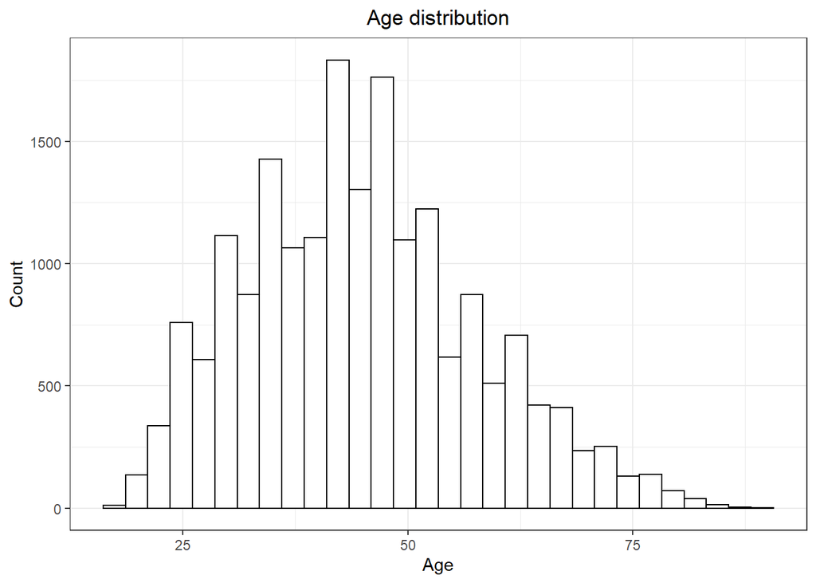

```r
#age
ggplot(insurance_data_dummied_short_no_outliers, aes(x=age))+
  geom_histogram(color="black", fill="white")+
  theme_bw()+
  labs(x="Age",y="Count",title="Age distribution")+
  theme(plot.title = element_text(hjust = 0.5))
```

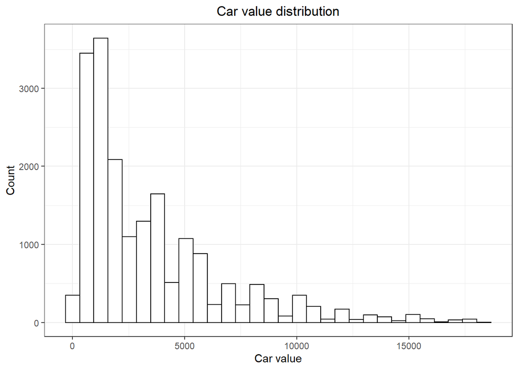

```r
#car value
ggplot(insurance_data_dummied_short_no_outliers, aes(x=car_value))+
  geom_histogram(color="black", fill="white")+
  theme_bw()+
  labs(x="Car value",y="Count",title="Car value distribution")+
  theme(plot.title = element_text(hjust = 0.5))
```

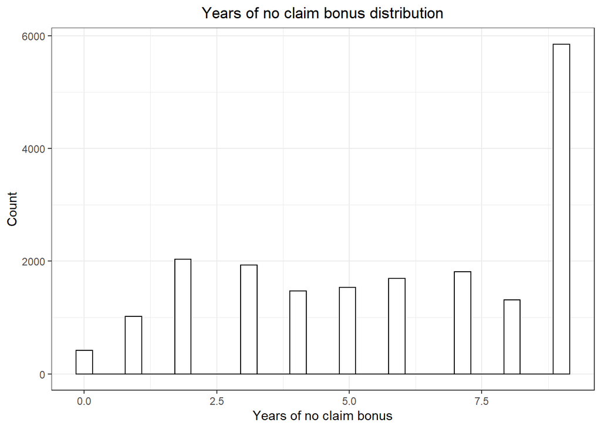

```r
#years of no claim bonus
ggplot(insurance_data_dummied_short_no_outliers, aes(x=years_of_no_claims_bonus))+
  geom_histogram(color="black", fill="white")+
  theme_bw()+
  labs(x="Years of no claim bonus",y="Count",title="Years of no claim bonus distribution")+
  theme(plot.title = element_text(hjust = 0.5))
```

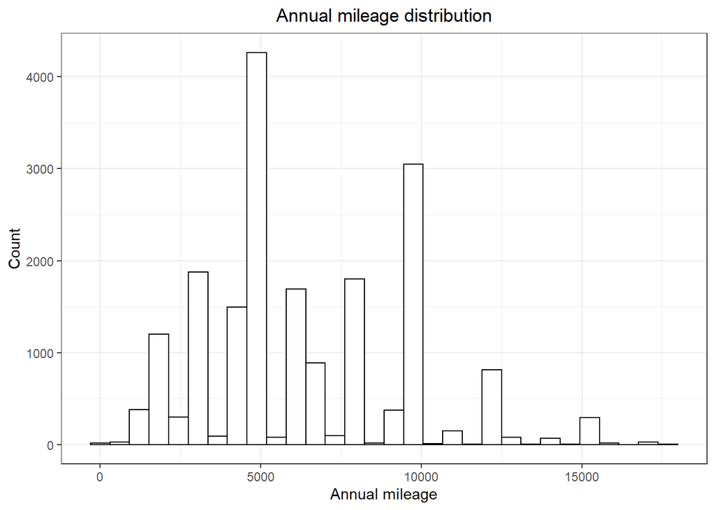

```r
#annual mileage
ggplot(insurance_data_dummied_short_no_outliers, aes(x=annual_mileage))+
  geom_histogram(color="black", fill="white")+
  theme_bw()+
  labs(x="Annual mileage",y="Count",title="Annual mileage distribution")+
  theme(plot.title = element_text(hjust = 0.5))
```

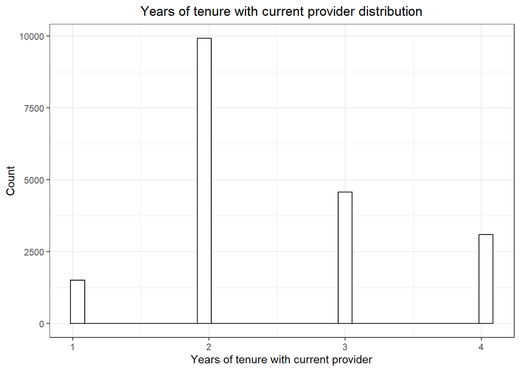

```r
#years of tenure with current provider
ggplot(insurance_data_dummied_short_no_outliers, aes(x=years_of_tenure_with_current_provider))+
  geom_histogram(color="black", fill="white")+
  theme_bw()+
  labs(x="Years of tenure with current provider",y="Count",title="Years of tenure with current provider distribution")+
  theme(plot.title = element_text(hjust = 0.5))
```

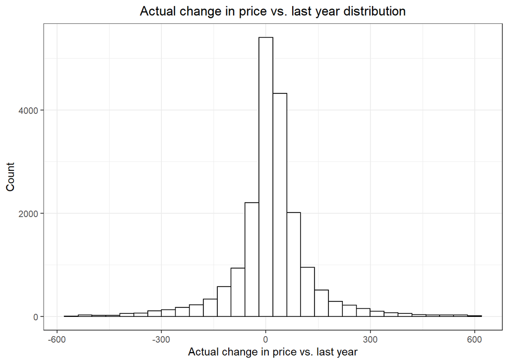

```r
#actual change in price vs. last year
ggplot(insurance_data_dummied_short_no_outliers, aes(x=actual_change_in_price_vs_last_year))+
  geom_histogram(color="black", fill="white")+
  theme_bw()+
  labs(x="Actual change in price vs. last year",y="Count",title="Actual change in price vs. last year distribution")+
  theme(plot.title = element_text(hjust = 0.5))
```

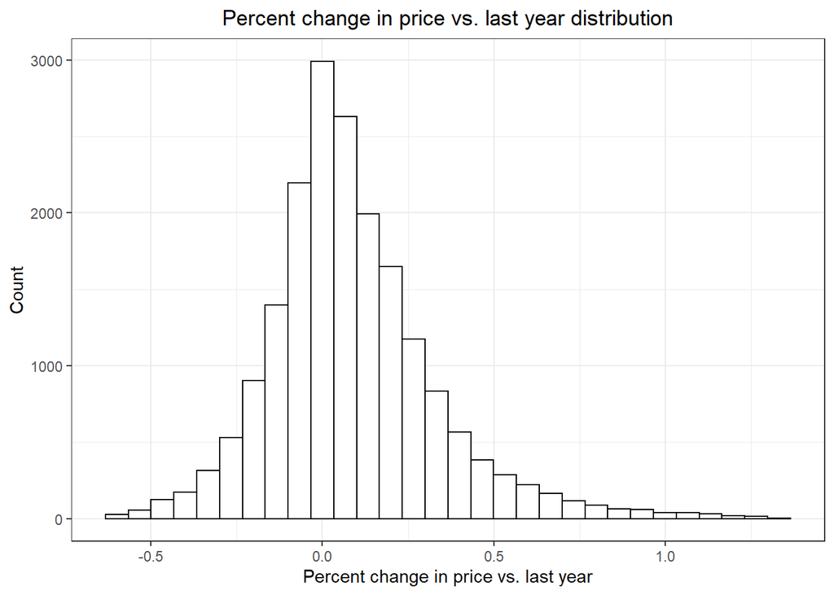

```r
#percent change in price vs. last year
ggplot(insurance_data_dummied_short_no_outliers, aes(x=percent_change_in_price_vs_last_year))+
  geom_histogram(color="black", fill="white")+
  theme_bw()+
  labs(x="Percent change in price vs. last year",y="Count",title="Percent change in price vs. last year distribution")+
  theme(plot.title = element_text(hjust = 0.5))
```

### 2.1.3. Vizualise the individual effect of each variable on price

Now that outliers have been removed, we can visualize the individual impact of each non-dummy variable on price.

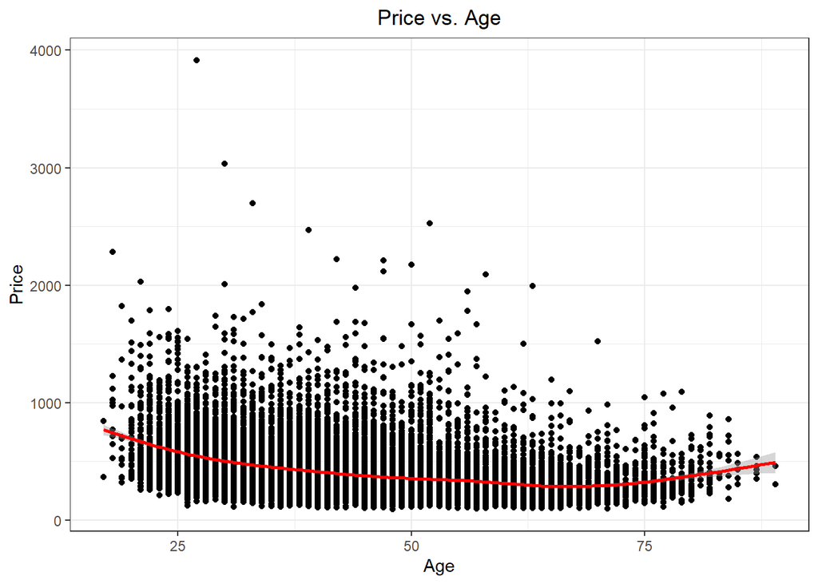

```r
#create scatter plots using ggplot and add a trend line to examine the impact of each variable on price

#price vs age
ggplot(insurance_data_dummied_short_no_outliers, aes(y=price,x=age))+
  geom_point()+
  geom_smooth(color="red")+
  theme_bw()+
  theme(plot.title = element_text(hjust = 0.5))+
  labs(title="Price vs. Age",x="Age",y="Price")
```

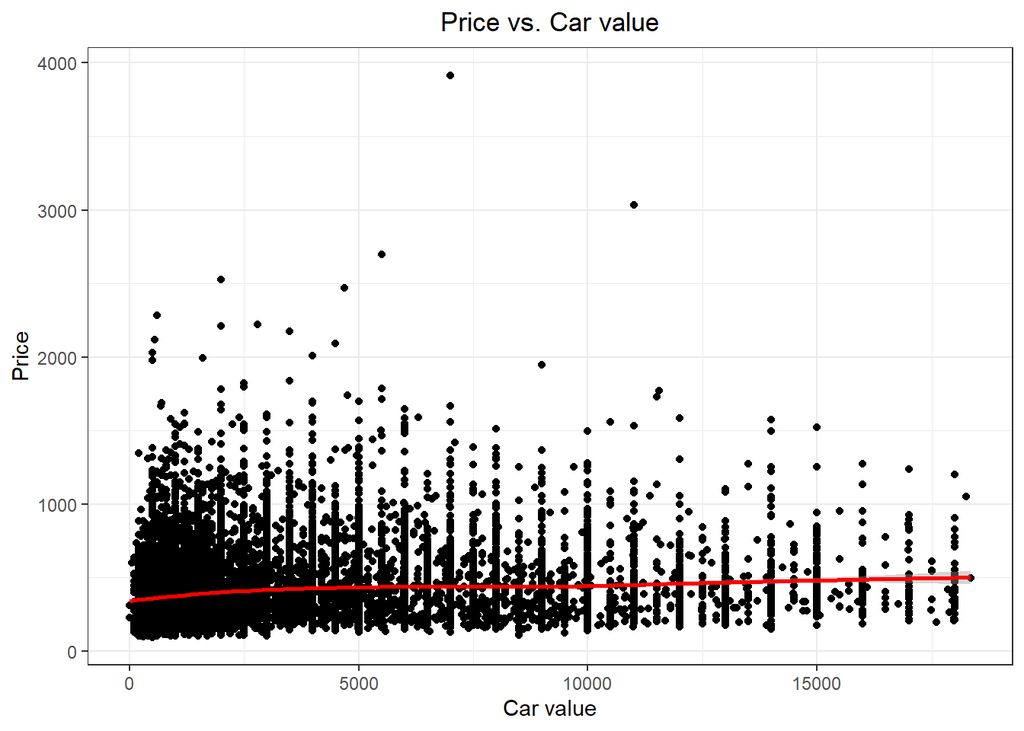

```r
#price vs car value
ggplot(insurance_data_dummied_short_no_outliers, aes(y=price,x=car_value))+
  geom_point()+
  geom_smooth(color="red")+
  theme_bw()+
  theme(plot.title = element_text(hjust = 0.5))+
  labs(title="Price vs. Car value",x="Car value",y="Price")
```

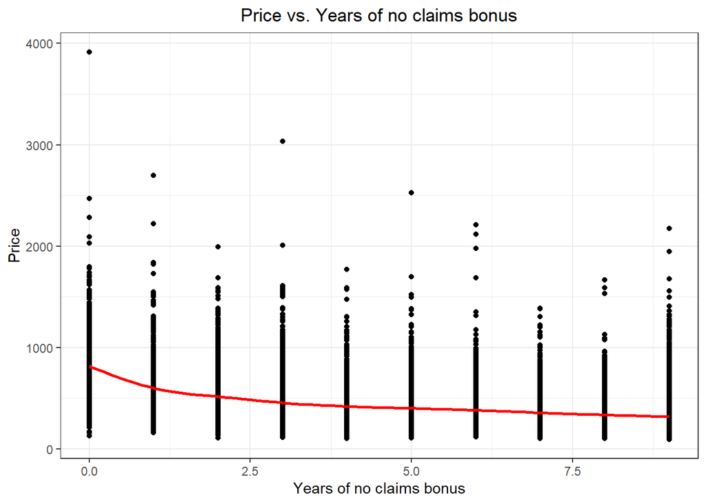

```r
#price vs years of no claim bonus
ggplot(insurance_data_dummied_short_no_outliers, aes(y=price,x=years_of_no_claims_bonus))+
  geom_point()+
  geom_smooth(color="red")+
  theme_bw()+
  theme(plot.title = element_text(hjust = 0.5))+
  labs(title="Price vs. Years of no claims bonus",x="Years of no claims bonus",y="Price")
```

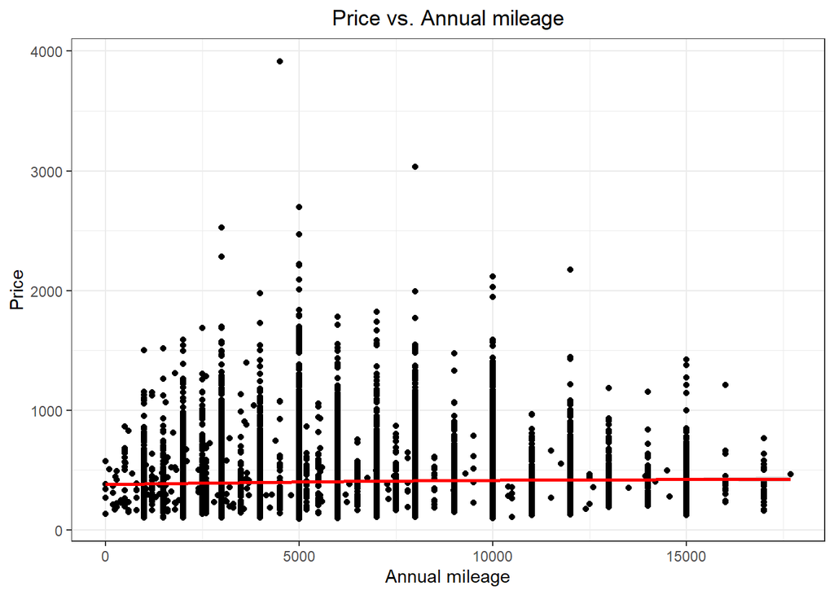

```r
#price vs annual mileage
ggplot(insurance_data_dummied_short_no_outliers, aes(y=price,x=annual_mileage))+
  geom_point()+
  geom_smooth(color="red")+
  theme_bw()+
  theme(plot.title = element_text(hjust = 0.5))+
  labs(title="Price vs. Annual mileage",x="Annual mileage",y="Price")
```

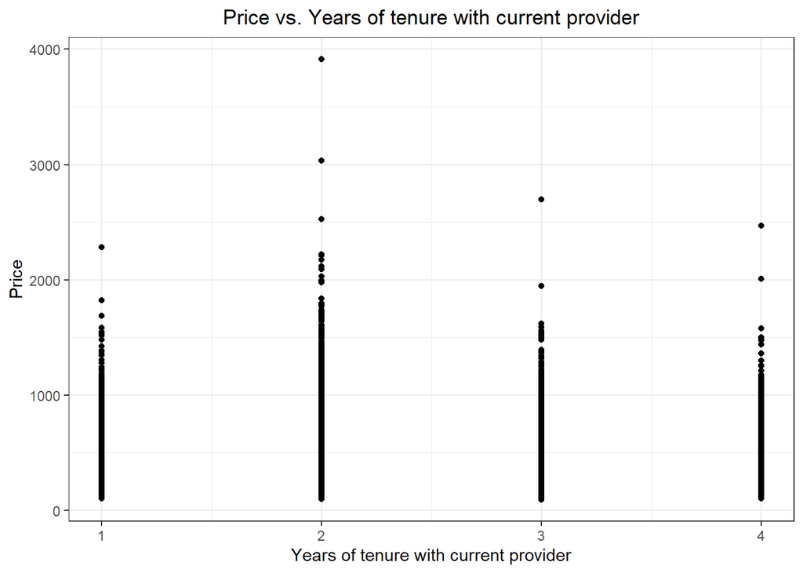

```r
#price vs years of tenure with current provider
ggplot(insurance_data_dummied_short_no_outliers, aes(y=price,x=years_of_tenure_with_current_provider))+
  geom_point()+
  geom_smooth(color="red")+
  theme_bw()+
  theme(plot.title = element_text(hjust = 0.5))+
  labs(title="Price vs. Years of tenure with current provider",x="Years of tenure with current provider",y="Price")
```

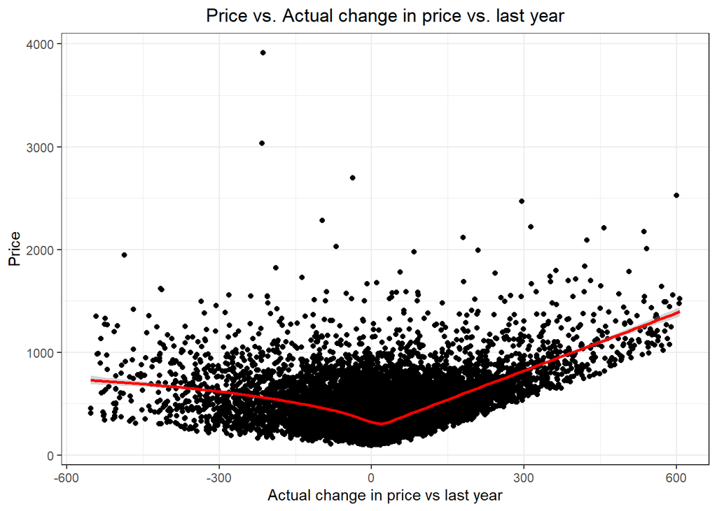

```r
#price vs actual change in price vs last year
ggplot(insurance_data_dummied_short_no_outliers, aes(y=price,x=actual_change_in_price_vs_last_year))+
  geom_point()+
  geom_smooth(color="red")+
  theme_bw()+
  theme(plot.title = element_text(hjust = 0.5))+
  labs(title="Price vs. Actual change in price vs. last year",x="Actual change in price vs last year",y="Price")
```

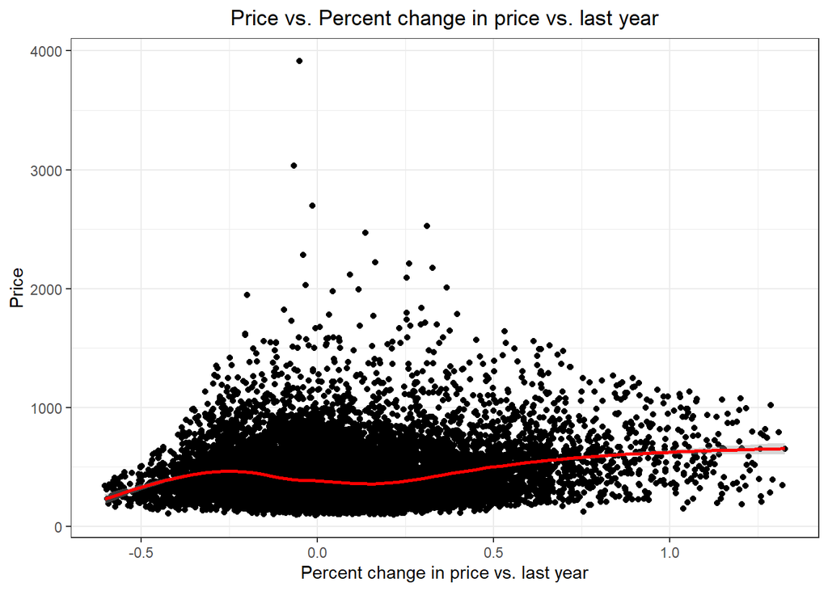

```r
#price vs percent change in price vs last year
ggplot(insurance_data_dummied_short_no_outliers, aes(y=price,x=percent_change_in_price_vs_last_year))+
  geom_point()+
  geom_smooth(color="red")+
  theme_bw()+
  theme(plot.title = element_text(hjust = 0.5))+
  labs(title="Price vs. Percent change in price vs. last year",x="Percent change in price vs. last year",y="Price")
```

## 2.2. Analyse the data and create linear regression models to predict the price

### 2.2.1. Create the models

Thanks to our data visualization above, we notice that an increase in the annual change in price vs last year has a negative impact on price when it is negative, and a positive impact on price when it is positive. This means that creating two linear regression models - one used when the actual change in price vs last year is negative, and one when it is positive - could yield a better result than create one linear regression model without any discrimination.

To examine if we can obtain better results using two models rather than one, we first create a linear regression model using all the statistically significant variables at a **95%** confidence interval (=> with a t-stat greater than **1.96**).

#### Linear regression

*Note: we get rid of the non statistically significant variables*

```r
#let us create a linear regression model for price using all non-dummy variables
lin_reg_full <- lm(price ~
                  age+
                  car_value+
                  years_of_no_claims_bonus+
                  annual_mileage+
                  years_of_tenure_with_current_provider+
                  actual_change_in_price_vs_last_year+
                  percent_change_in_price_vs_last_year+
                  renewed+marital_status_d+
                  marital_status_m+
                  marital_status_s+
                  marital_status_v+
                  gender_f+
                  gender_m+
                  payment_method_annual+
                  acquisition_channel_aggreg+
                  acquisition_channel_direct+
                  acquisition_channel_inbound,
                data = insurance_data_dummied_short)
summary(lin_reg_full)
```

```
##
## Call:
## lm(formula = price ~ age + car_value + years_of_no_claims_bonus +
##     annual_mileage + years_of_tenure_with_current_provider +
##     actual_change_in_price_vs_last_year + percent_change_in_price_vs_last_year +
##     renewed + marital_status_d + marital_status_m + marital_status_s +
##     marital_status_v + gender_f + gender_m + payment_method_annual +
##     acquisition_channel_aggreg + acquisition_channel_direct +
##     acquisition_channel_inbound, data = insurance_data_dummied_short)
##
## Residuals:
##     Min      1Q  Median      3Q     Max
## -2638.3  -119.0   -34.4    65.2  3404.7
##
## Coefficients:
##                                         Estimate Std. Error t value Pr(>|t|)
## (Intercept)                            8.573e+02  1.360e+02   6.304 2.96e-10
## age                                   -4.099e+00  1.516e-01 -27.045  < 2e-16
## car_value                              1.509e-02  4.053e-04  37.223  < 2e-16
## years_of_no_claims_bonus              -3.071e+01  5.808e-01 -52.881  < 2e-16
## annual_mileage                        -2.051e-04  4.437e-04  -0.462    0.644
## years_of_tenure_with_current_provider -1.370e+01  1.839e+00  -7.449 9.77e-14
## actual_change_in_price_vs_last_year    9.680e-02  3.762e-03  25.734  < 2e-16
## percent_change_in_price_vs_last_year   2.344e+00  4.816e-01   4.866 1.15e-06
## renewed                               -7.082e+01  3.259e+00 -21.734  < 2e-16
## marital_status_d                      -7.707e+01  1.182e+01  -6.523 7.07e-11
## marital_status_m                      -6.337e+01  1.077e+01  -5.882 4.13e-09
## marital_status_s                      -4.631e+01  1.125e+01  -4.118 3.84e-05
## marital_status_v                      -1.065e+02  2.616e+01  -4.071 4.70e-05
## gender_f                              -5.186e+01  4.887e+01  -1.061    0.289
## gender_m                               1.632e+01  4.884e+01   0.334    0.738
## payment_method_annual                 -6.030e+01  3.786e+00 -15.925  < 2e-16
## acquisition_channel_aggreg             7.359e+01  1.407e+02   0.523    0.601
## acquisition_channel_direct             7.417e+00  1.260e+02   0.059    0.953
## acquisition_channel_inbound            4.221e+01  1.259e+02   0.335    0.737
##
## (Intercept)                           ***
## age                                   ***
## car_value                             ***
## years_of_no_claims_bonus              ***
## annual_mileage
## years_of_tenure_with_current_provider ***
## actual_change_in_price_vs_last_year   ***
## percent_change_in_price_vs_last_year  ***
## renewed                               ***
## marital_status_d                      ***
## marital_status_m                      ***
## marital_status_s                      ***
## marital_status_v                      ***
## gender_f
## gender_m
## payment_method_annual                 ***
## acquisition_channel_aggreg
## acquisition_channel_direct
## acquisition_channel_inbound
## ---
## Signif. codes:  0 '***' 0.001 '**' 0.01 '*' 0.05 '.' 0.1 ' ' 1
##
## Residual standard error: 218 on 19998 degrees of freedom
## Multiple R-squared:  0.3106, Adjusted R-squared:   0.31
## F-statistic: 500.7 on 18 and 19998 DF,  p-value: < 2.2e-16
```

```r
#we remove one by one variables with absolute t-values <2 starting with the smallest: acquisition_channel_direct, gender_m, annual_mileage and acquisition_channel_aggreg
lin_reg_sig <- lm(price ~
                  age+
                  car_value+
                  years_of_no_claims_bonus+
                  years_of_tenure_with_current_provider+
                  actual_change_in_price_vs_last_year+
                  percent_change_in_price_vs_last_year+
                  renewed+
                  marital_status_d+
                  marital_status_m+
                  marital_status_s+
                  marital_status_v+
                  gender_f+
                  payment_method_annual+
                  acquisition_channel_inbound,
                data = insurance_data_dummied_short)
summary(lin_reg_sig)
```

```
##
## Call:
## lm(formula = price ~ age + car_value + years_of_no_claims_bonus +
##     years_of_tenure_with_current_provider + actual_change_in_price_vs_last_year +
##     percent_change_in_price_vs_last_year + renewed + marital_status_d +
##     marital_status_m + marital_status_s + marital_status_v +
##     gender_f + payment_method_annual + acquisition_channel_inbound,
##     data = insurance_data_dummied_short)
##
## Residuals:
##     Min      1Q  Median      3Q     Max
## -2638.0  -119.2   -34.5    65.1  3405.2
##
## Coefficients:
##                                         Estimate Std. Error t value Pr(>|t|)
## (Intercept)                            8.797e+02  1.498e+01  58.711  < 2e-16
## age                                   -4.096e+00  1.511e-01 -27.107  < 2e-16
## car_value                              1.506e-02  3.977e-04  37.865  < 2e-16
## years_of_no_claims_bonus              -3.072e+01  5.800e-01 -52.963  < 2e-16
## years_of_tenure_with_current_provider -1.361e+01  1.836e+00  -7.413 1.29e-13
## actual_change_in_price_vs_last_year    9.678e-02  3.761e-03  25.735  < 2e-16
## percent_change_in_price_vs_last_year   2.344e+00  4.816e-01   4.868 1.14e-06
## renewed                               -7.078e+01  3.257e+00 -21.733  < 2e-16
## marital_status_d                      -7.714e+01  1.180e+01  -6.534 6.55e-11
## marital_status_m                      -6.348e+01  1.076e+01  -5.898 3.74e-09
## marital_status_s                      -4.640e+01  1.124e+01  -4.129 3.67e-05
## marital_status_v                      -1.068e+02  2.616e+01  -4.081 4.49e-05
## gender_f                              -6.798e+01  3.184e+00 -21.352  < 2e-16
## payment_method_annual                 -6.012e+01  3.782e+00 -15.896  < 2e-16
## acquisition_channel_inbound            3.456e+01  3.939e+00   8.773  < 2e-16
##
## (Intercept)                           ***
## age                                   ***
## car_value                             ***
## years_of_no_claims_bonus              ***
## years_of_tenure_with_current_provider ***
## actual_change_in_price_vs_last_year   ***
## percent_change_in_price_vs_last_year  ***
## renewed                               ***
## marital_status_d                      ***
## marital_status_m                      ***
## marital_status_s                      ***
## marital_status_v                      ***
## gender_f                              ***
## payment_method_annual                 ***
## acquisition_channel_inbound           ***
## ---
## Signif. codes:  0 '***' 0.001 '**' 0.01 '*' 0.05 '.' 0.1 ' ' 1
##
## Residual standard error: 218 on 20002 degrees of freedom
## Multiple R-squared:  0.3106, Adjusted R-squared:  0.3101
## F-statistic: 643.7 on 14 and 20002 DF,  p-value: < 2.2e-16
```

#### Linear regression with interaction terms

We now create a linear regression with interaction terms that account for the sign (<0 or >0) of the actual change in price vs. last year by creeating two columns.

```r
#create a column which takes the value of the actual change in price if this change is positive, and zero otherwise
insurance_data_dummied_short$actual_change_in_price_vs_last_year_pos <- insurance_data_dummied_short$actual_change_in_price_vs_last_year
insurance_data_dummied_short$actual_change_in_price_vs_last_year_pos[insurance_data_dummied_short$actual_change_in_price_vs_last_year_pos<0] <- "0"
insurance_data_dummied_short$actual_change_in_price_vs_last_year_pos <- as.numeric(insurance_data_dummied_short$actual_change_in_price_vs_last_year_pos)

#create a column which takes the value of the actual change in price if this change is strictly negative, and zero otherwise
insurance_data_dummied_short$actual_change_in_price_vs_last_year_neg <- insurance_data_dummied_short$actual_change_in_price_vs_last_year
insurance_data_dummied_short$actual_change_in_price_vs_last_year_neg[insurance_data_dummied_short$actual_change_in_price_vs_last_year_neg>=0] <- "0"
insurance_data_dummied_short$actual_change_in_price_vs_last_year_neg <- as.numeric(insurance_data_dummied_short$actual_change_in_price_vs_last_year_neg)

#run our linear regression with the interaction terms (we remove the variable of actual change in price since this data is now encompassed in our new two interaction terms)
lin_reg_act_pric_disc <- lm(price ~
                  age+
                  car_value+
                  years_of_no_claims_bonus+
                  years_of_tenure_with_current_provider+
                  percent_change_in_price_vs_last_year+
                  renewed+
                  marital_status_d+
                  marital_status_m+
                  marital_status_s+
                  marital_status_v+
                  gender_f+
                  payment_method_annual+
                  acquisition_channel_inbound+
                  actual_change_in_price_vs_last_year_pos+
                  actual_change_in_price_vs_last_year_neg,
                data = insurance_data_dummied_short)
summary(lin_reg_act_pric_disc)
```

```
##
## Call:
## lm(formula = price ~ age + car_value + years_of_no_claims_bonus +
##     years_of_tenure_with_current_provider + percent_change_in_price_vs_last_year +
##     renewed + marital_status_d + marital_status_m + marital_status_s +
##     marital_status_v + gender_f + payment_method_annual + acquisition_channel_inbound +
##     actual_change_in_price_vs_last_year_pos + actual_change_in_price_vs_last_year_neg,
##     data = insurance_data_dummied_short)
##
## Residuals:
##     Min      1Q  Median      3Q     Max
## -5774.8  -114.3   -32.2    63.6  3263.3
##
## Coefficients:
##                                           Estimate Std. Error t value Pr(>|t|)
## (Intercept)                              8.460e+02  1.470e+01  57.551  < 2e-16
## age                                     -3.930e+00  1.479e-01 -26.566  < 2e-16
## car_value                                1.437e-02  3.898e-04  36.878  < 2e-16
## years_of_no_claims_bonus                -2.911e+01  5.699e-01 -51.080  < 2e-16
## years_of_tenure_with_current_provider   -1.372e+01  1.796e+00  -7.640 2.26e-14
## percent_change_in_price_vs_last_year     2.334e+00  4.711e-01   4.953 7.37e-07
## renewed                                 -6.580e+01  3.190e+00 -20.625  < 2e-16
## marital_status_d                        -7.615e+01  1.155e+01  -6.594 4.40e-11
## marital_status_m                        -6.032e+01  1.053e+01  -5.728 1.03e-08
## marital_status_s                        -4.228e+01  1.100e+01  -3.845 0.000121
## marital_status_v                        -9.884e+01  2.559e+01  -3.862 0.000113
## gender_f                                -6.616e+01  3.115e+00 -21.237  < 2e-16
## payment_method_annual                   -5.893e+01  3.700e+00 -15.924  < 2e-16
## acquisition_channel_inbound              3.543e+01  3.853e+00   9.195  < 2e-16
## actual_change_in_price_vs_last_year_pos  1.821e-01  4.651e-03  39.154  < 2e-16
## actual_change_in_price_vs_last_year_neg -5.784e-02  6.334e-03  -9.131  < 2e-16
##
## (Intercept)                             ***
## age                                     ***
## car_value                               ***
## years_of_no_claims_bonus                ***
## years_of_tenure_with_current_provider   ***
## percent_change_in_price_vs_last_year    ***
## renewed                                 ***
## marital_status_d                        ***
## marital_status_m                        ***
## marital_status_s                        ***
## marital_status_v                        ***
## gender_f                                ***
## payment_method_annual                   ***
## acquisition_channel_inbound             ***
## actual_change_in_price_vs_last_year_pos ***
## actual_change_in_price_vs_last_year_neg ***
## ---
## Signif. codes:  0 '***' 0.001 '**' 0.01 '*' 0.05 '.' 0.1 ' ' 1
##
## Residual standard error: 213.2 on 20001 degrees of freedom
## Multiple R-squared:  0.3403, Adjusted R-squared:  0.3398
## F-statistic: 687.7 on 15 and 20001 DF,  p-value: < 2.2e-16
```

We observe that we obtain adjusted R-squared of **0.3398** when we add two interaction terms to discriminate for the sign (<0 or >0) of the actual change in price vs. last year, vs **0.3101** when we do not.

### 2.2.2. Backtest the models

We now want to back test our models to see if disriminating based on the change in actual price indeed yields better results. We train our models on a random sample of **60%** of the data, and test it on the remaining **40%**.

#### Linear regression back-testing

```r
#define the sample size
smp_size <- floor(0.6 * nrow(insurance_data_dummied_short))
set.seed(123)
train_ind <- sample(seq_len(nrow(insurance_data_dummied_short)), size = smp_size)

#breakdown our data in a training and a testing sets
insurance_data_dummied_short_train <- insurance_data_dummied_short[train_ind, ]
insurance_data_dummied_short_test <- insurance_data_dummied_short[-train_ind, ]

#train our model
lin_reg_sig_trained <- lm(price ~
                  age+
                  car_value+
                  years_of_no_claims_bonus+
                  years_of_tenure_with_current_provider+
                  actual_change_in_price_vs_last_year+
                  percent_change_in_price_vs_last_year+
                  renewed+
                  marital_status_d+
                  marital_status_m+
                  marital_status_s+
                  marital_status_v+
                  gender_f+
                  payment_method_annual+
                  acquisition_channel_inbound,
                data = insurance_data_dummied_short_train)
summary(lin_reg_sig_trained)
```

```
##
## Call:
## lm(formula = price ~ age + car_value + years_of_no_claims_bonus +
##     years_of_tenure_with_current_provider + actual_change_in_price_vs_last_year +
##     percent_change_in_price_vs_last_year + renewed + marital_status_d +
##     marital_status_m + marital_status_s + marital_status_v +
##     gender_f + payment_method_annual + acquisition_channel_inbound,
##     data = insurance_data_dummied_short_train)
##
## Residuals:
##     Min      1Q  Median      3Q     Max
## -2392.9  -119.0   -35.1    61.9  3201.5
##
## Coefficients:
##                                         Estimate Std. Error t value Pr(>|t|)
## (Intercept)                            8.936e+02  1.923e+01  46.476  < 2e-16
## age                                   -4.265e+00  1.956e-01 -21.805  < 2e-16
## car_value                              1.528e-02  5.147e-04  29.683  < 2e-16
## years_of_no_claims_bonus              -3.070e+01  7.500e-01 -40.927  < 2e-16
## years_of_tenure_with_current_provider -1.552e+01  2.386e+00  -6.507 7.96e-11
## actual_change_in_price_vs_last_year    1.866e-01  7.012e-03  26.610  < 2e-16
## percent_change_in_price_vs_last_year   1.182e+00  4.902e-01   2.412 0.015864
## renewed                               -6.870e+01  4.225e+00 -16.260  < 2e-16
## marital_status_d                      -8.090e+01  1.508e+01  -5.365 8.25e-08
## marital_status_m                      -6.821e+01  1.370e+01  -4.978 6.52e-07
## marital_status_s                      -5.340e+01  1.433e+01  -3.727 0.000195
## marital_status_v                      -1.487e+02  3.462e+01  -4.295 1.76e-05
## gender_f                              -6.788e+01  4.120e+00 -16.475  < 2e-16
## payment_method_annual                 -6.106e+01  4.889e+00 -12.491  < 2e-16
## acquisition_channel_inbound            3.600e+01  5.095e+00   7.065 1.70e-12
##
## (Intercept)                           ***
## age                                   ***
## car_value                             ***
## years_of_no_claims_bonus              ***
## years_of_tenure_with_current_provider ***
## actual_change_in_price_vs_last_year   ***
## percent_change_in_price_vs_last_year  *
## renewed                               ***
## marital_status_d                      ***
## marital_status_m                      ***
## marital_status_s                      ***
## marital_status_v                      ***
## gender_f                              ***
## payment_method_annual                 ***
## acquisition_channel_inbound           ***
## ---
## Signif. codes:  0 '***' 0.001 '**' 0.01 '*' 0.05 '.' 0.1 ' ' 1
##
## Residual standard error: 218.7 on 11995 degrees of freedom
## Multiple R-squared:  0.3239, Adjusted R-squared:  0.3231
## F-statistic: 410.5 on 14 and 11995 DF,  p-value: < 2.2e-16
```

```r
#test our model
lin_reg_sig_tested_data <- data.frame(predict(lin_reg_sig_trained, newdata = insurance_data_dummied_short_test))
lin_reg_sig_tested_vs_reality <- cbind(lin_reg_sig_tested_data,insurance_data_dummied_short_test$price)
colnames(lin_reg_sig_tested_vs_reality) <- c("predicted","reality")

#compute the mean squared error and the mean absolute error
lin_reg_sig_tested_vs_reality$squared_error <- (lin_reg_sig_tested_vs_reality$predicted - lin_reg_sig_tested_vs_reality$reality)^2
lin_reg_sig_tested_vs_reality$absolute_error <- abs((lin_reg_sig_tested_vs_reality$predicted - lin_reg_sig_tested_vs_reality$reality))
lin_reg_sig_tested_vs_reality$absolute_error_perc <- abs(((lin_reg_sig_tested_vs_reality$predicted - lin_reg_sig_tested_vs_reality$reality))/lin_reg_sig_tested_vs_reality$predicted)*100
mse_lin_reg_sig = mean(lin_reg_sig_tested_vs_reality$squared_error)
mae_lin_reg_sig = mean(lin_reg_sig_tested_vs_reality$absolute_error)
mape_lin_reg_sig = mean(lin_reg_sig_tested_vs_reality$absolute_error_perc)
mse_lin_reg_sig
```

```
## [1] 50453.13
```

```r
mae_lin_reg_sig
```

```
## [1] 136.5454
```

```r
mape_lin_reg_sig
```

```
## [1] 33.59408
```

#### Linear regression with interaction terms back-testing

```r
#train our model
lin_reg_act_pric_disc_trained <- lm(price ~
                  age+
                  car_value+
                  years_of_no_claims_bonus+
                  years_of_tenure_with_current_provider+
                  percent_change_in_price_vs_last_year+
                  renewed+
                  marital_status_d+
                  marital_status_m+
                  marital_status_s+
                  marital_status_v+
                  gender_f+
                  payment_method_annual+
                  acquisition_channel_inbound+
                  actual_change_in_price_vs_last_year_pos+
                  actual_change_in_price_vs_last_year_neg,
                data = insurance_data_dummied_short_train)
summary(lin_reg_act_pric_disc_trained)
```

```
##
## Call:
## lm(formula = price ~ age + car_value + years_of_no_claims_bonus +
##     years_of_tenure_with_current_provider + percent_change_in_price_vs_last_year +
##     renewed + marital_status_d + marital_status_m + marital_status_s +
##     marital_status_v + gender_f + payment_method_annual + acquisition_channel_inbound +
##     actual_change_in_price_vs_last_year_pos + actual_change_in_price_vs_last_year_neg,
##     data = insurance_data_dummied_short_train)
##
## Residuals:
##     Min      1Q  Median      3Q     Max
## -6604.5  -106.3   -28.8    60.1  3120.1
##
## Coefficients:
##                                           Estimate Std. Error t value Pr(>|t|)
## (Intercept)                              8.091e+02  1.812e+01  44.657  < 2e-16
## age                                     -3.923e+00  1.833e-01 -21.404  < 2e-16
## car_value                                1.390e-02  4.830e-04  28.786  < 2e-16
## years_of_no_claims_bonus                -2.673e+01  7.088e-01 -37.719  < 2e-16
## years_of_tenure_with_current_provider   -1.470e+01  2.234e+00  -6.581 4.86e-11
## percent_change_in_price_vs_last_year     7.335e-01  4.590e-01   1.598  0.11009
## renewed                                 -5.690e+01  3.966e+00 -14.346  < 2e-16
## marital_status_d                        -7.220e+01  1.412e+01  -5.114 3.21e-07
## marital_status_m                        -6.151e+01  1.283e+01  -4.794 1.66e-06
## marital_status_s                        -4.344e+01  1.342e+01  -3.238  0.00121
## marital_status_v                        -1.301e+02  3.242e+01  -4.015 5.99e-05
## gender_f                                -6.224e+01  3.860e+00 -16.124  < 2e-16
## payment_method_annual                   -5.985e+01  4.577e+00 -13.077  < 2e-16
## acquisition_channel_inbound              3.951e+01  4.771e+00   8.282  < 2e-16
## actual_change_in_price_vs_last_year_pos  4.515e-01  9.197e-03  49.090  < 2e-16
## actual_change_in_price_vs_last_year_neg -1.339e-01  1.019e-02 -13.143  < 2e-16
##
## (Intercept)                             ***
## age                                     ***
## car_value                               ***
## years_of_no_claims_bonus                ***
## years_of_tenure_with_current_provider   ***
## percent_change_in_price_vs_last_year
## renewed                                 ***
## marital_status_d                        ***
## marital_status_m                        ***
## marital_status_s                        **
## marital_status_v                        ***
## gender_f                                ***
## payment_method_annual                   ***
## acquisition_channel_inbound             ***
## actual_change_in_price_vs_last_year_pos ***
## actual_change_in_price_vs_last_year_neg ***
## ---
## Signif. codes:  0 '***' 0.001 '**' 0.01 '*' 0.05 '.' 0.1 ' ' 1
##
## Residual standard error: 204.8 on 11994 degrees of freedom
## Multiple R-squared:  0.4075, Adjusted R-squared:  0.4067
## F-statistic: 549.8 on 15 and 11994 DF,  p-value: < 2.2e-16
```

```r
#test our model
lin_reg_act_pric_disc_tested_data <- data.frame(predict(lin_reg_act_pric_disc_trained, newdata = insurance_data_dummied_short_test))
lin_reg_act_pric_disc_tested_vs_reality <- cbind(lin_reg_act_pric_disc_tested_data,insurance_data_dummied_short_test$price)
colnames(lin_reg_act_pric_disc_tested_vs_reality) <- c("predicted","reality")

#compute the mean squared error and the mean absolute error
lin_reg_act_pric_disc_tested_vs_reality$squared_error <- (lin_reg_act_pric_disc_tested_vs_reality$predicted - lin_reg_act_pric_disc_tested_vs_reality$reality)^2
lin_reg_act_pric_disc_tested_vs_reality$absolute_error <- abs((lin_reg_act_pric_disc_tested_vs_reality$predicted - lin_reg_act_pric_disc_tested_vs_reality$reality))
lin_reg_act_pric_disc_tested_vs_reality$absolute_error_perc <- abs(((lin_reg_act_pric_disc_tested_vs_reality$predicted - lin_reg_act_pric_disc_tested_vs_reality$reality))/lin_reg_act_pric_disc_tested_vs_reality$predicted)*100
mse_lin_reg_act_pric_disc = mean(lin_reg_act_pric_disc_tested_vs_reality$squared_error)
mae_lin_reg_act_pric_disc = mean(lin_reg_act_pric_disc_tested_vs_reality$absolute_error)
mape_lin_reg_act_pric_disc = mean(lin_reg_act_pric_disc_tested_vs_reality$absolute_error_perc)
mse_lin_reg_act_pric_disc
```

```
## [1] 70449.54
```

```r
mae_lin_reg_act_pric_disc
```

```
## [1] 126.7465
```

```r
mape_lin_reg_act_pric_disc
```

```
## [1] 29.73929
```

### 2.2.3. Compare our models

Now that we backtested our linear regression models, we can compare them.

```r
#compare the 6 models we ran: the 3 linear regressions ran on the full sample and the 3 linear regressions ran on the testing sample
huxreg(lin_reg_sig, lin_reg_act_pric_disc, lin_reg_sig_trained, lin_reg_act_pric_disc_trained)
```

|  | (1) | (2) | (3) | (4) |
| --- | --- | --- | --- | --- |
| (Intercept) | 879.654 *** | 846.011 *** | 893.624 *** | 809.102 *** |
|  | (14.983) | (14.700) | (19.228) | (18.118) |
| age | -4.096 *** | -3.930 *** | -4.265 *** | -3.923 *** |
|  | (0.151) | (0.148) | (0.196) | (0.183) |
| car_value | 0.015 *** | 0.014 *** | 0.015 *** | 0.014 *** |
|  | (0.000) | (0.000) | (0.001) | (0.000) |
| years_of_no_claims_bonus | -30.719 *** | -29.112 *** | -30.697 *** | -26.734 *** |
|  | (0.580) | (0.570) | (0.750) | (0.709) |
| years_of_tenure_with_current_provider | -13.611 *** | -13.724 *** | -15.524 *** | -14.700 *** |
|  | (1.836) | (1.796) | (2.386) | (2.234) |
| actual_change_in_price_vs_last_year | 0.097 *** |  | 0.187 *** |  |
|  | (0.004) |  | (0.007) |  |
| percent_change_in_price_vs_last_year | 2.344 *** | 2.334 *** | 1.182 * | 0.733 |
|  | (0.482) | (0.471) | (0.490) | (0.459) |
| renewed | -70.780 *** | -65.802 *** | -68.701 *** | -56.897 *** |
|  | (3.257) | (3.190) | (4.225) | (3.966) |
| marital_status_d | -77.135 *** | -76.146 *** | -80.901 *** | -72.199 *** |
|  | (11.805) | (11.549) | (15.080) | (14.119) |
| marital_status_m | -63.482 *** | -60.323 *** | -68.212 *** | -61.505 *** |
|  | (10.764) | (10.530) | (13.703) | (12.830) |
| marital_status_s | -46.404 *** | -42.282 *** | -53.400 *** | -43.438 ** |
|  | (11.240) | (10.997) | (14.328) | (13.416) |
| marital_status_v | -106.767 *** | -98.841 *** | -148.693 *** | -130.142 *** |
|  | (26.159) | (25.592) | (34.623) | (32.418) |
| gender_f | -67.977 *** | -66.156 *** | -67.883 *** | -62.240 *** |
|  | (3.184) | (3.115) | (4.120) | (3.860) |
| payment_method_annual | -60.124 *** | -58.926 *** | -61.064 *** | -59.850 *** |
|  | (3.782) | (3.700) | (4.889) | (4.577) |
| acquisition_channel_inbound | 34.557 *** | 35.432 *** | 35.996 *** | 39.512 *** |
|  | (3.939) | (3.853) | (5.095) | (4.771) |
| actual_change_in_price_vs_last_year_pos |  | 0.182 *** |  | 0.451 *** |
|  |  | (0.005) |  | (0.009) |
| actual_change_in_price_vs_last_year_neg |  | -0.058 *** |  | -0.134 *** |
|  |  | (0.006) |  | (0.010) |
| N | 20017 | 20017 | 12010 | 12010 |
| R2 | 0.311 | 0.340 | 0.324 | 0.407 |
| logLik | -136173.905 | -135733.824 | -81741.371 | -80949.269 |
| AIC | 272379.811 | 271501.648 | 163514.743 | 161932.538 |
| *** p < 0.001; ** p < 0.01; * p < 0.05. |  |  |  |  |

```r
#finally, we compare the adjusted R-squared, MSE and MAE of a linear regression vs the weighted average of the linear regression which distriminate for the sign of the actual change in price vs last year
lin_reg_r2 <- 0.3101
lin_reg_disc_r2 <- 0.3398

mse_lin_reg_sig <- format(round(unlist(as.numeric(mse_lin_reg_sig,0))), nsmall = 0)
mse_lin_reg_act_pric_disc <- mse_lin_reg_act_pric_disc <- format(round(unlist(as.numeric(mse_lin_reg_act_pric_disc,0))), nsmall = 0)
mae_lin_reg_sig <- mae_lin_reg_sig <- format(round(unlist(as.numeric(mae_lin_reg_sig,0))), nsmall = 0)
mae_lin_reg_act_pric_disc <- mae_lin_reg_act_pric_disc <- format(round(unlist(as.numeric(mae_lin_reg_act_pric_disc,0))), nsmall = 0)
mape_lin_reg_sig <- mape_lin_reg_sig <- format(round(unlist(as.numeric(mape_lin_reg_sig,0))), nsmall = 0)
mape_lin_reg_act_pric_disc <- mape_lin_reg_act_pric_disc <- format(round(unlist(as.numeric(mape_lin_reg_act_pric_disc,0))), nsmall = 0)

total_comparables <- data.frame(cbind(lin_reg_r2,lin_reg_disc_r2))
total_comparables[nrow(total_comparables)+1,] <- cbind(mse_lin_reg_sig,mse_lin_reg_act_pric_disc)
total_comparables[nrow(total_comparables)+1,] <- cbind(mae_lin_reg_sig,mae_lin_reg_act_pric_disc)
total_comparables[nrow(total_comparables)+1,] <- cbind(mape_lin_reg_sig,mape_lin_reg_act_pric_disc)
total_comparables[2,] <- prettyNum(total_comparables[2,],big.mark=",",scientific=FALSE)

colnames(total_comparables) <- c("Linear regression","Linear regression based on sign of actual price change (weighted average)")
rownames(total_comparables) <- c("Ajudsted R-Square","Mean Square Error (back tested)","Mean Absolute Error (back tested)","Mean Absolute Percentage Error (back tested)")

metrics_names <- rownames(total_comparables)
total_comparables <- cbind(metrics_names,total_comparables)
colnames(total_comparables) <- c("Metrics","Linear regression","Linear regression disc. for actual price change")

total_comparables
```

| Metrics | Linear regression | Linear regression disc. for actual price change |
| --- | --- | --- |
| Ajudsted R-Square | 0.3101 | 0.3398 |
| Mean Square Error (back tested) | 50,453 | 70,450 |
| Mean Absolute Error (back tested) | 137 | 127 |
| Mean Absolute Percentage Error (back tested) | 34 | 30 |

When looking at the tables, we see than regressing the price for the statistically significant variables gives us an adjusted R-squared of **0.3101**, vs **0.3398** when we use interaction terms. This is a **9.58%** improvement in the accuracy of our model.

This is to be expected because, as explained above, an increase in the actual change in price vs. last year has a negative effect on price when it is negative, but a positive impact when it is positive. The overall effect is positive, but running a linear regression without interaction terms “waters down” that effect. The coefficient for the actual change in price vs last year is indeed **0.097** overall, but **0.182** when positive and **-0.058** when negative.

Analyzing the data to a greater extent could help coming up with more interaction terms that could improve further the predictive power of our model.

```r
log_reg_full <- glm(formula = renewed ~ age+
                      car_value+
                      years_of_no_claims_bonus+
                      annual_mileage+
                      years_of_tenure_with_current_provider+
                      actual_change_in_price_vs_last_year+
                      percent_change_in_price_vs_last_year+
                      marital_status_d+
                      marital_status_m+
                      marital_status_s+
                      marital_status_v+
                      gender_f+
                      gender_m+
                      payment_method_annual+
                      acquisition_channel_aggreg+
                      acquisition_channel_direct+
                      acquisition_channel_inbound,
                    data = insurance_data_dummied_short)
summary(log_reg_full)
```

```
##
## Call:
## glm(formula = renewed ~ age + car_value + years_of_no_claims_bonus +
##     annual_mileage + years_of_tenure_with_current_provider +
##     actual_change_in_price_vs_last_year + percent_change_in_price_vs_last_year +
##     marital_status_d + marital_status_m + marital_status_s +
##     marital_status_v + gender_f + gender_m + payment_method_annual +
##     acquisition_channel_aggreg + acquisition_channel_direct +
##     acquisition_channel_inbound, data = insurance_data_dummied_short)
##
## Deviance Residuals:
##     Min       1Q   Median       3Q      Max
## -1.8443  -0.5450   0.2829   0.3636   1.4323
##
## Coefficients:
##                                         Estimate Std. Error t value Pr(>|t|)
## (Intercept)                            1.134e-01  2.951e-01   0.384 0.700727
## age                                    3.710e-03  3.278e-04  11.316  < 2e-16
## car_value                             -1.507e-06  8.795e-07  -1.714 0.086523
## years_of_no_claims_bonus               8.225e-03  1.259e-03   6.534 6.57e-11
## annual_mileage                        -3.722e-06  9.625e-07  -3.867 0.000110
## years_of_tenure_with_current_provider  2.881e-02  3.986e-03   7.228 5.09e-13
## actual_change_in_price_vs_last_year   -5.465e-05  8.153e-06  -6.703 2.09e-11
## percent_change_in_price_vs_last_year  -3.629e-03  1.045e-03  -3.473 0.000515
## marital_status_d                       4.865e-03  2.564e-02   0.190 0.849506
## marital_status_m                       3.195e-02  2.338e-02   1.367 0.171733
## marital_status_s                       4.082e-02  2.440e-02   1.673 0.094411
## marital_status_v                       3.693e-02  5.678e-02   0.650 0.515411
## gender_f                              -1.652e-01  1.060e-01  -1.558 0.119347
## gender_m                              -1.818e-01  1.060e-01  -1.715 0.086328
## payment_method_annual                 -2.259e-01  8.059e-03 -28.033  < 2e-16
## acquisition_channel_aggreg             5.582e-01  3.054e-01   1.828 0.067570
## acquisition_channel_direct             4.625e-01  2.734e-01   1.692 0.090711
## acquisition_channel_inbound            4.572e-01  2.733e-01   1.673 0.094364
##
## (Intercept)
## age                                   ***
## car_value                             .
## years_of_no_claims_bonus              ***
## annual_mileage                        ***
```

[output cut: 8 more lines]

```
## gender_m                              .
## payment_method_annual                 ***
## acquisition_channel_aggreg            .
## acquisition_channel_direct            .
## acquisition_channel_inbound           .
## ---
## Signif. codes:  0 '***' 0.001 '**' 0.01 '*' 0.05 '.' 0.1 ' ' 1
##
## (Dispersion parameter for gaussian family taken to be 0.2237426)
##
##     Null deviance: 4709.1  on 20016  degrees of freedom
## Residual deviance: 4474.6  on 19999  degrees of freedom
## AIC: 26855
##
## Number of Fisher Scoring iterations: 2
```